# Exterior Algebra

### **NOTES ON STATISTICS, PROBABILITY and MATHEMATICS**

### The big idea:

There is a [(musical) isomorphism](https://en.wikipedia.org/wiki/Musical_isomorphism) between the tangent bundle and the cotangent bundle induced by the metric tensor. See [here](https://math.stackexchange.com/a/127377/152225).

A given vector field can be automatically “converted” into a “work” 1-form field (or differential 1-form field) as in [here](https://youtu.be/Ps4mXhfxiRI):

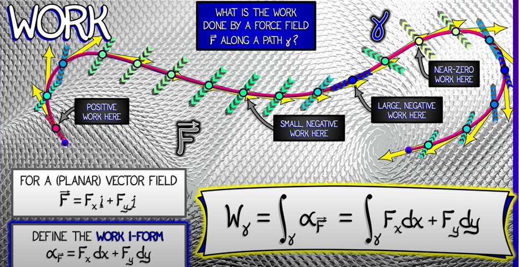

or a “flux” 1-form (orthogonal) to the work one form:

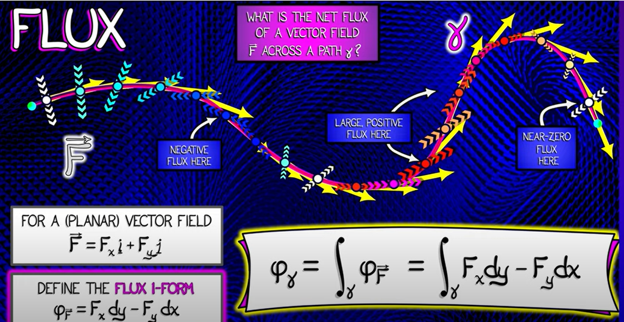

Both forms can be integrated over a path.

Now, differentiating forms will yield the gradient (exterior derivative of 0-forms), curl (exterior derivative of 1-forms) and divergence (exterior derivative of 2-forms).

And the integration of these derivatives will come full-circle in Stokes’ theorem:

$$\int_{\partial M} \omega= \int_{M}
d\omega$$

### The mechanics of integrating forms:

From [here](https://youtu.be/NXUKzKRcfLU):

Integrating the 1-form

$$\alpha = -y\,dx+ x\,dy$$

along a circle at the origin of radius $R.$

Fixing a counterclocwise path

$$\gamma(t)=\begin{bmatrix} R\cos t\\
R\sin t \end{bmatrix}$$

the matrix of derivatives is

$$\gamma'(t)=\begin{bmatrix} -R\sin
t\\ R\cos t \end{bmatrix}$$
$$\begin{align}
\int_\gamma \alpha &=\int_{t=a}^b
\alpha_{\gamma(t)}\left(\gamma'(t) \right)\,dt \\[2ex]
&=\int_{t=0}^{2\pi}\left(-R\sin t \,dx + R\cos t \,dy \right)\;
\begin{bmatrix} -R\sin t\\ R\cos t \end{bmatrix}\, dt \\[2ex]
&=\int_{t=0}^{2\pi} R^2 \sin^2t + R^2\cos^2t\,dt
\end{align}=$$

From [here](https://youtu.be/dTxAERk0E0s):

Integrating the 2-form

$$\beta = (x + y)^2\, dx\wedge dy -
z\,dy\wedge dz$$

over the upper hemisphere

$$z = \sqrt{c^2 - x^2 - y^2} \geq
0$$

Parameterizing as

$$G\begin{bmatrix} x \\ y \\ \sqrt{c^2 -
x^2 - y^2} \end{bmatrix}$$

and the matrix of derivatives is

$$G\begin{bmatrix} 1 & 0 \\ 0 & 1
\\ \frac{-x}{\sqrt{c^2 - x^2 - y^2}} & \frac{-y}{\sqrt{c^2 - x^2 -
y^2}} \end{bmatrix}$$

Therefore,

$$\begin{align}
\int \beta &= \int\int (x+y)^2 \begin{vmatrix}
1&0\\0&1\end{vmatrix}- \sqrt{c^2 - x^2 - y^2}\begin{vmatrix} 0
& 1 \\ \frac{-x}{\sqrt{c^2 - x^2 - y^2}} & \frac{-y}{\sqrt{c^2
- x^2 - y^2}} \end{vmatrix}\;dxdy\\[2ex]
&=\int\int_{x^2+y^2+c^2} (x+y)^2 +x \; dxdy
\end{align}$$

### Exterior Derivative:

An $m$ differential form in $\mathbb R^n$ can be expressed in multi-index notation as

$$\begin{align}
\omega &= \sum_I f_I \; dx_I \\
&= \sum_{1 \leq i_1 < i_2 \ \dots <i_m} a_{i_1, \dots, i_m} \;
dx_1 \wedge dx_2 \wedge \dots \wedge dx_m \\\\
&I=(i_1, i_2, \dots,i_m) \; \mid\; 1 \leq i_1 < i_2 \ \dots
<i_m \leq n
\end{align}$$

From [here](https://www.youtube.com/watch?v=4--S4N8YDmE&t=54s&ab_channel=MichaelPenn) and from [here](https://www.youtube.com/watch?v=jeiDXhCiF44&list=PL9_jI1bdZmz0hIrNCMQW1YmZysAiIYSSS&index=8&ab_channel=KeenanCrane):

For an $\omega$ $m$-form on $\mathbb R^n$:

$$\omega = \sum_I f_I \, dx_I$$

the exterior derivative is

$$d\omega= \sum_I \sum_{j=1}^n
\frac{\partial f_I}{\partial x_j}\,dx_j \wedge dx_I$$

Therefore, the output is an $m+1$ form in $\mathbb R^n$

So for just $f \, dx_I,$

$$d(f\; dx_I)= \frac{\partial f}{\partial
x_1}\,dx_1 \wedge dx_I + \frac{\partial f}{\partial x_2}\,dx_2 \wedge
dx_I+\cdots + \frac{\partial f}{\partial x_n}\,dx_n \wedge
dx_I$$

with $dx_I = dx_{i_1}\wedge \dots \wedge dx_{i_m}$ and the multi-index $I =(i_{1},\dots, i_m)$

The **exterior derivative $\rm d$ of a $0$-form** or function $\phi$ is (in $3$-dimensions for ease of notation):

$$d\phi=\frac{\partial \phi}{\partial x}dx
+ \frac{\partial \phi}{\partial y}dy+ \frac{\partial \phi}{\partial
z}dz$$

This takes a vector field $d\phi(X)=D_X\phi$ and gives the directional derivative along that vector field.

How does it relate to the **gradient**? $(d\phi)^\sharp = \nabla \phi$ (sharp), and $(\nabla \phi)^\flat = d\phi$ (flat).

The **exterior derivative of a $1$-differential form** (a $1$-form is just a fixed value in front of the elementary forms $dx_i$, whereas a “differential form” implies a function in front of the elementary forms - i.e. a field of forms) $\omega = F_x \,dx + F_y \,dy + Fz \,dz,$ where $F_x, F_y, F_z$ are the corresponding functions (the sub-index here is not meant to indicate a partial derivative) in $3$ dimensions is

$$\begin{align}
\frac{\partial F_x}{\partial x} \; dx \wedge dx + \frac{\partial
F_y}{\partial x} \; dx \wedge dy + \frac{\partial F_z}{\partial x} \; dx
\wedge dz \\[2ex]
+ \frac{\partial F_x}{\partial y} \; dy \wedge dx + \frac{\partial
F_y}{\partial y} \; dy \wedge dy + \frac{\partial F_z}{\partial y} \; dy
\wedge dz \\[2ex]
+ \frac{\partial F_x}{\partial z} \; dz \wedge dx + \frac{\partial
F_y}{\partial z} \; dz \wedge dy + \frac{\partial F_z}{\partial z} \; dz
\wedge dz
\end{align} \\[2ex]
= \frac{\partial F_z}{\partial y} - \frac{\partial F_y}{\partial z}\; dy
\wedge dz \quad+\quad \frac{\partial F_x}{\partial z} - \frac{\partial
F_z}{\partial x}\; dz \wedge dx \quad + \quad\frac{\partial
F_y}{\partial x} - \frac{\partial F_x}{\partial y}\; dx \wedge
dy$$

which looks a lot like the **curl** (from here):

$$\nabla \times {\bf F}=\begin{bmatrix}
\frac{\partial F_z}{\partial y} - \frac{\partial F_y}{\partial z}\\
\frac{\partial F_x}{\partial z} - \frac{\partial F_z}{\partial x}\\
\frac{\partial F_y}{\partial x} - \frac{\partial F_x}{\partial y}
\end{bmatrix}$$

We can see that they are related because $\star d\omega = \nabla \times {\bf F}$ and $\nabla \times {\bf F} = (\star dF^\flat)^\sharp.$ We can see the first relationship to the Hodge star in noticing that the complementary of $dx\wedge dy$ is $dz$, and the rows of the expression for the curl right above correspond to the vector components $\partial / \partial x, \partial/\partial y,\partial/\partial z$ respectively.

What is the relation to Green’s theorem? The **circulation form of Green’s theorem** states

$$\int_{\partial D}
\underset{1-\text{form}}{\underbrace{F_x \,dx +
Fy\,dy}}=\int\int_D\underset{z \text{ component
curl}}{\underbrace{\frac{\partial F_y}{\partial x}- \frac{\partial
F_x}{\partial y}}}\, dA$$
The integrand in the RHS is also the $\frac{\partial F_y}{\partial x} - \frac{\partial F_x}{\partial y}\; dx \wedge dy$ component of the exterior derivative. Green’s theorem is just in the plane but the analogy with Stokes’ theorem is clear:

$$\int_{\partial D} \omega = \int_D
d\omega$$

Similarly, the **flux form of Green’s theorem** can be derived by remembering that the flux is orthogonal to the original field, and that, again, we are on a plane with Green’s theorem. The form to integrate is not $F_x \, dx + F_y \, dy,$ but rather $F_x \, dy - F_y \,dx.$ And going through the exterior derivative, and obtaining the $dx \wedge dy$ component results in:

$$\int_{\partial D} F_x \, dy - F_y \,dx=
\int\int_{D} \underset{\text{divergence}}{\underbrace{\frac{\partial
F_x}{\partial x} + \frac{\partial F_y}{\partial y}}} \;dA$$

Note (from [here](https://sites.und.edu/timothy.prescott/apex/web/apex.Ch15.S4.html)): As for the LHS of the equation above, with $\partial D$ traversed counterclockwise by $\vec r=\langle f(t), g(t) \rangle$ the tangent is

$$T'=\frac{\langle f'(t),
g'(t) \rangle}{\Vert \vec r'(t)\Vert}$$

and the normal

$$n'=\frac{\langle g'(t), -
f'(t) \rangle}{\Vert \vec r'(t)\Vert}$$

and

$$\begin{align}
\int_{\partial D} \vec F \cdot \vec n\, ds &= \int_{\partial D} \vec
F \cdot \frac{\langle g'(t), - f'(t) \rangle}{\Vert \vec
r'(t)\Vert}\Vert \vec r'(t)\Vert \, dt \\[2ex]
&=\int_{\partial D}\langle F_x,F_y \rangle \cdot \langle g'(t),
- f'(t) \rangle dt \\[2ex]
&= \int_{\partial D} F_x \, g'(t) dt- \int_{\partial D}F_y \,
f'(t) dt \\[2ex]
&=\int_{\partial D} F_x \, dy - \int_{\partial D} F_y \, dx\\[2ex]
&=\int_{\partial D} F_x \, dy - F_y \, dx
\end{align}$$

Finally, **the exterior derivative of a $2$-differential form** $\beta=F\, dx\wedge dy + G\, dx\wedge dz + H\, dy\wedge dz$ is

$$d\beta = \frac{\partial F}{\partial z}\;
dz\wedge dx \wedge dy + \frac{\partial F}{\partial y}\; dy\wedge dx
\wedge dz + \frac{\partial F}{\partial x}\; dx\wedge dy \wedge dz=\left(
\frac{\partial F}{\partial x} - \frac{\partial F}{\partial
y}+\frac{\partial F}{\partial z} \right) dx\wedge dy \wedge
dz$$

That minus sign is annoying, but it is still true that the exterior derivative of the Hodge star (see [here](https://youtu.be/tyaWHQO-wSc?t=134)) of a $1$-form $\omega = F_x \,dx + F_y \,dy + Fz \,dz$ is

$$\begin{align}
d(\star w)&=d(\star( F_x \,dx + F_y \,dy + F_z \,dz))\\[2ex]
&=d(F_x\, dy \wedge dz + F_y\, dz\wedge dx + F_z \, dx\wedge
dy)\\[2ex]
&=dF_x\wedge dy \wedge dz + dF_y\wedge dz\wedge dx + dF_z\wedge dx
\wedge dy\\[2ex]
&=\frac{\partial F_x}{\partial x}dx\wedge dy \wedge dz +
\frac{\partial F_y}{\partial y}dy\wedge dz \wedge dx + \frac{\partial
F_z}{\partial z}dz\wedge dx \wedge dy \\[2ex]
&=\left(\frac{\partial F_x}{\partial x}+ \frac{\partial
F_y}{\partial y}+ \frac{\partial F_z}{\partial z}\right) dx\wedge
dy\wedge dz
\end{align}$$

NOTE on the Hodge star operator: $dy\wedge dz$ is the Hodge star of $dx$ because $dx \wedge dy \wedge dz$, i.e. $dx \wedge \star dx = dx\wedge dy\wedge dz$ returns the elementary $n$ form. Likewise for $dy$ the Hodge star is $dz\wedge dx$ because $dy \wedge dz \wedge dx= dx \wedge dy \wedge dz$ since commuting two elements doesn’t change the sign.

We have then that $\star d \star \omega= \nabla \cdot X,$ where $\nabla \cdot X$ is the **divergence** of a vector field. Notice that $\omega = X^\flat.$ Therefore the divergence is $\star d \star X^\flat$.

### Wedge or Exterior Product:

An $m$ differential form in $\mathbb R^n$ can be expressed in multi-index notation as

$$\begin{align}
\omega &= \sum_I f_I \; dx_I \\
&= \sum_{1 \leq i_1 < i_2 \ \dots <i_m} a_{i_1, \dots, i_m} \;
dx_1 \wedge dx_2 \wedge \dots \wedge dx_m \\\\
&I=(i_1, i_2, \dots,i_m) \; \mid\; 1 \leq i_1 < i_2 \ \dots
<i_m \leq n
\end{align}$$

In $\mathbb R^5$, we can construct $1$-forms using the $dx$ elementary forms of the dual basis $(1,3),(1,2,3,4,5)$ or $(2,4,5):$

$$\begin{align}
\color{blue}{dx_1} && dx_2 &&\color{blue}{dx_3}
&& dx_4 && dx_5 \\
\color{orange}{dx_1} && \color{orange}{dx_2} &&
\color{orange}{dx_3} && \color{orange}{dx_4} &&
\color{orange}{dx_5} \\
dx_1 && \color{red}{dx_2} && {dx_3} &&
\color{red}{dx_4} && \color{red}{dx_5} && \\
\end{align}$$

These are not the multi-indices above, which correspond to wedged dual basis elements.

Here are three $1$-forms:

$$\begin{align}\omega_1 &=
-7\,\color{blue}{dx_1} + 3 \,\color{blue}{dx_3}\\
\omega_2 &=-1 \,\color{orange}{dx_1} + \color{orange}{dx_2} +
\color{orange}{dx_3}-4\,\color{orange}{d_4} + 5\,\color{orange}{dx_5}\\
\omega_3 &=-2 \,\color{red}{dx_2} + \color{red}{dx_4} -
\color{red}{dx_5}
\end{align}$$

A $3$-form results from wedging $\omega_1 \wedge \omega_2\wedge \omega_3.$

It acts on three vectors in $\mathbb R^5,$ such as

$$\begin{align}\small v_1
&=\begin{bmatrix}1&&2 &&-1&& 0
&&5\end{bmatrix}\\ v_2 &=\begin{bmatrix}0&&0
&&1&& 10 &&1\end{bmatrix}\\ v_3
&=\begin{bmatrix}7&&1 &&0&& 3
&&2\end{bmatrix}
\end{align}$$

as

$$\small\omega_1 \wedge \omega_2\wedge
\omega_3\;(v_1,v_2,v_3)=\begin{vmatrix} (-7)\cdot1
+3\cdot(-1)=\color{blue}{-10}&&(-1)\cdot1+1\cdot2+1\cdot(-1)+(-4)\cdot0+5\cdot5=\color{orange}{25}
&&
(-2)\cdot2+1\cdot0+(-1)\cdot5=\color{red}{-9}\\(-7)\cdot0+3\cdot1=\color{blue}{3}&&(-1)\cdot0+1\cdot0+1\cdot1+(-4)\cdot10+5\cdot1=\color{orange}{-34}
&&(-2)\cdot0+1\cdot10+(-1)\cdot1=\
\color{red}{9}\\(-7)\cdot7+3\cdot0=\color{blue}{-49}&&(-1)\cdot7+1\cdot1+1\cdot0+(-4)\cdot3+5\cdot2=\color{orange}{-8}
&&
(-2)\cdot1+1\cdot3+(-1)\cdot2=\color{red}{-1}\end{vmatrix}=3200$$

Trying to express it as in the multi-index notation above invoves distributing the wedged $1$-forms:

$$\begin{align}
\omega_1 \wedge \omega_2\wedge \omega_3
&=\Tiny\left( -7\, dx_1+ 3\,dx_3\right)\wedge
\left(-1\,dx_1 + dx_2 + dx_3-4\,dx_4 + 5\,dx_5 \right) \wedge
\left(-2\,dx_2 + dx_4 - dx_5 \right)\\
&\Tiny=(
-7 \, dx_1\wedge dx_2
- 7\, dx_1\wedge dx_3
+28\, dx_1 \wedge dx_4
-35\,dx_1\wedge dx_5
+3 dx_1\wedge dx_3\\
&\Tiny -3\,dx_2\wedge dx_3
- 12\,dx_3\wedge dx_4) + 15 \, dx_3 \wedge dx_5\\
&\Tiny\wedge \Tiny \left(-2\,dx_2 + dx_4 - dx_5 \right)=\\
& \small -8\,dx_1\wedge dx_2 \wedge dx_3\\
& \small + 49\,dx_1\wedge dx_2 \wedge dx_4 \\
& \small - 63\, dx_1\wedge dx_2 \wedge dx_5 \\
&\small -4\, dx_1\wedge dx_3 \wedge dx_4 \\
& \small + 4 \, dx_1\wedge dx_3 \wedge dx_5\\
& \small +7 \, dx_1\wedge dx_4 \wedge dx_5\\
&\small + 21\, dx_2\wedge dx_3 \wedge dx_4\\
&\small - 27\, dx_2\wedge dx_3 \wedge dx_5\\
&\small - 3\, dx_3\wedge dx_4 \wedge dx_5
\end{align}$$

which applied to the vectors above:

$$\Tiny
-8 \begin{vmatrix} 1& 2 & -1 \\ 0&0&1\\7&1&0
\end{vmatrix}
+49\begin{vmatrix} 1&2&0 \\ 0&0&10\\7&1&3
\end{vmatrix}
-63\begin{vmatrix} 1&2&5 \\ 0&0&1\\7&1&2
\end{vmatrix}
-4 \begin{vmatrix} 1&-1&0 \\ 0&1&10\\7&0&3
\end{vmatrix}
+ 4 \begin{vmatrix} 1&-1&5 \\ 0&1&1\\7&0&2
\end{vmatrix}
+7 \begin{vmatrix} 1&0&5 \\ 0&10&1\\7&3&2
\end{vmatrix}
+21 \begin{vmatrix} 2&-1&0 \\ 0&1&10\\1&0&3
\end{vmatrix}
-27 \begin{vmatrix} 2&-1&5 \\ 0&1&1\\1&0&2
\end{vmatrix}
-3 \begin{vmatrix} -1&0&5 \\ 1&10&1\\0&3&2
\end{vmatrix}=3200$$

```r
m = matrix(c(-10,25,-9,3,-34,9,-49,-8,-1),3,byrow=T)
m
```

```
##      [,1] [,2] [,3]
## [1,]  -10   25   -9
## [2,]    3  -34    9
## [3,]  -49   -8   -1
```

```r
det(m)
```

```
## [1] 3200
```

```r
one = matrix(c(1,2,-1,0,0,1,7,1,0),3,byrow=T)
two = matrix(c(1,2,0,0,0,10,7,1,3),3,byrow=T)
three = matrix(c(1,2,5,0,0,1,7,1,2),3,byrow=T)
four = matrix(c(1,-1,0,0,1,10,7,0,3),3,byrow=T)
five = matrix(c(1,-1,5,0,1,1,7,0,2),3,byrow=T)
six = matrix(c(1,0,5,0,10,1,7,3,2),3,byrow=T)
seven = matrix(c(2,-1,0,0,1,10,1,0,3),3,byrow=T)
eight = matrix(c(2,-1,5,0,1,1,1,0,2),3,byrow=T)
nine = matrix(c(-1,0,5,1,10,1,0,3,2),3,byrow=T)

-8*det(one)  +49*det(two)  -63*det(three) -4*det(four) +4*det(five) +7*det(six) +21*det(seven) -27*det(eight) -3*det(nine)
```

```
## [1] 3200
```

Here is another example:

$$\begin{align}\omega_1 &= dx + dy +
dz\\
\omega_2 &=2\, dx - 3 \, dy\\
\omega_3 &=dx + 2\, dz
\end{align}$$

A $3$-form can be the result of wedging $\omega_1 \wedge \omega_2\wedge \omega_3.$

It acts on three vectors in $\mathbb R^3,$ such as

$$\begin{align}\small v_1
&=\begin{bmatrix}2&1 &0\end{bmatrix}\\ v_2
&=\begin{bmatrix}-1&3&-2\end{bmatrix}\\ v_3
&=\begin{bmatrix}1&0&1\end{bmatrix}
\end{align}$$

$$\omega_1 \wedge \omega_2\wedge
\omega_3\;(v_1,v_2,v_3)=\begin{vmatrix}3&&1 &&
2\\0&&-11&& -5\\2&&2 &&
3\end{vmatrix}=-35$$

```r
det(M <- matrix(c(3,1,2,0,-11,-5,2,2,3),3,byrow=T))
```

```
## [1] -35
```

```r
M
```

```
##      [,1] [,2] [,3]
## [1,]    3    1    2
## [2,]    0  -11   -5
## [3,]    2    2    3
```

If instead we distribute as

$$\begin{align}
(dx + dy + dz) \wedge (2dx - 3dy) \wedge (dx+2dz) &= (-3\,dx\wedge
dy - 2\,dx\wedge dy -2\,dx\wedge dz+3\,dy\wedge dz )\wedge (dx+2dz)\\
&= (-5\,dx\wedge dy -2\,dx\wedge dz+3\,dy\wedge dz)\wedge
(dx+2dz)\\
&= -10\, dx\wedge dy \wedge dz + 3 dx \wedge dy \wedge dz \\
&= - 7\, dx\wedge dy \wedge dz
\end{align}$$

```r
-7 * det(Q <- matrix(c(2,1,0,-1,3,-2,1,0,1),3,byrow=T))
```

```
## [1] -35
```

```r
Q
```

```
##      [,1] [,2] [,3]
## [1,]    2    1    0
## [2,]   -1    3   -2
## [3,]    1    0    1
```

In reference to the explanation of the [exterior or wedge product](https://en.wikipedia.org/wiki/Exterior_algebra) by Prof. Shifrin’s series (Chapter 8 - [here](https://youtu.be/Nh5XFX0iKgE), [here](https://youtu.be/ZFPWK2gHGrY) and [here](https://youtu.be/Rci22jC_pS8)), and connecting it with the more general [tensor algebra](https://math.stackexchange.com/a/2436543/152225) operations, here is a summary:

The dual vector space $V^*=(\mathbb R^n)^*$ is a vector space of linear maps $\mathbb R^n \to \mathbb R$ that can be represented by a $1\times n$ matrix (i.e. row vector). It is isomorphic to $\mathbb R^n,$ and forms a vector space, which basis can be expressed as $\mathrm e^1,\mathrm e^2,\dots,\mathrm e^n,$ or as $\mathrm dx_1, \mathrm dx_2, \dots ,\mathrm dx_n,$ such that $\mathrm dx_i(\vec v)=\vec {\mathrm e}_i\cdot \vec v.$

This dual vector space constitutes the specific case of the vector space of alternating multilinear maps, denoted $\Lambda^k(\mathbb R^n)^*$ when $k=1.$ For example, in 3-dimensional Euclidean space, i.e. $n=3,$ a possible form would be $7\mathrm dx_2=7\mathrm dy=7\mathrm e^2,$ and if this is fed a vector $\vec v=\begin{bmatrix}-7&8&2\end{bmatrix}^\top,$ the result will be simply the dot product $\small\begin{bmatrix}0&7&0\end{bmatrix}\begin{bmatrix}-7\\8\\2\end{bmatrix}=56.$

As a vector space, these forms can be added (and scalar multiplied), so that $4\mathrm dx +7 \mathrm dy=\begin{bmatrix}4&7&0\end{bmatrix},$ an expression naturally belonging to the same vector space $\Lambda^1(\mathbb R^3)^*,$ and also accepting vectors in $\mathbb R^3$ to produce a real number through the dot product operation.

The wedge product of two such forms in $\Lambda^1(\mathbb R^3)^*$ will result in an element in $\Lambda^2(\mathbb R^3)^*.$ For example, taking the last element of $\Lambda^1(\mathbb R^3)^*$ in the preceding example, i.e. $\psi =4\mathrm dx_1 +7 \mathrm dx_2,$ and wedging it with $\varphi =2\mathrm dx_1 +5 \mathrm dx_3,$ also in the same vector space $\Lambda^1(\mathbb R^3)^*,$ we obtain

$$\psi\wedge\varphi=4\mathrm dx_1 +7
\mathrm dx_2 \wedge 2\mathrm dx_1 +5 \mathrm dx_3=-14\;\mathrm
dx_{12}+20\;\mathrm d_{13}+35\; \mathbb d_{23}\tag 1$$

Critically, this is the same as picturing the two forms in $\Lambda^1(\mathbb R^3)^*,$ i.e. $4\mathrm dx_1 +7 \mathrm dx_2=\color{red}{\begin{bmatrix}4&7&0\end{bmatrix}}^\top$ and $2\mathrm dx_1 +5 \mathrm dx_3=\color{blue}{\begin{bmatrix}2&0&5\end{bmatrix}}^\top$ as

$$\begin{bmatrix}
\color{red}4&\color{red}7&\color{red}0\\
\color{blue}2& \color{blue} 0 & \color{blue}5
\end{bmatrix}$$

and realizing that $\mathrm d_{12}$ is simply the determinant of the first two columns (minor of the submatrix):

$$\det{\begin{bmatrix}
\color{red}4&\color{red}7\\
\color{blue}2& \color{blue} 0
\end{bmatrix}}=-14$$

and that $\mathrm d_{13}$

$$\det{\begin{bmatrix}
\color{red}4&\color{red}0\\
\color{blue}2& \color{blue} 5
\end{bmatrix}}=20$$

with $\mathrm d_{23}$

$$\det{\begin{bmatrix}
\color{red}7&\color{red}0\\
\color{blue}0& \color{blue} 5
\end{bmatrix}}=35$$

We could express this as

$$\psi\wedge\varphi=\sum \text
{minors}_{ij}\; \mathrm d_{ij}$$

The wedge product can be carried out between vector spaces $\Lambda^l(\mathbb R^n)^*\wedge \Lambda^k(\mathbb R^n)^*\in \Lambda^{l+k}(\mathbb R^n)^*.$

This all comes together when two vectors in $\mathbb R^3$ are fed into the expression in Eq (1), for example
$$\small\vec p
=\begin{bmatrix}-1&-\pi&-\sqrt 2\end{bmatrix}^\top$$
and
$$\small\vec q
=\begin{bmatrix}10^1&10^2&10^3\end{bmatrix}^\top:$$

$$\begin{align}\left(\psi \wedge
\varphi\right)(p,q) &=
-14\,\mathrm dx_{12}(p,q) + 20 \,\mathrm dx_{13}(p,q) + 35\, \mathrm
dx_{23}(p,q)\\[2ex]
&=-14 \,\begin{vmatrix}-1&10 \\-\pi & 10^2\end{vmatrix}+
20\, \begin{vmatrix}-1 & 10 \\-\sqrt 2 & 10^3\end{vmatrix} +
35\,
\begin{vmatrix}-\pi & 10^2 \\-\sqrt 2 & 10^3\end{vmatrix}
\end{align}$$

As for the equivalence to tensor algebra pointed out in the answer

$$\begin{align}
\mathrm dx_{12}(p,q)&=\mathrm dx_1 \wedge \mathrm dx_2 (p,q)\\[2ex]
&= \left(\mathrm dx_1 \otimes \mathrm dx_2 - \mathrm dx_2\otimes
\mathrm dx_1\right)(p,q)\\[2ex]
&= (\mathrm dx_1 \otimes \mathrm dx_2 )(p,q)-(\mathrm dx_2\otimes
\mathrm dx_1)(p,q)\\[2ex]
&=\mathrm dx_1(p)\,\mathrm dx_2(q) - \mathrm dx_2(p) \,\mathrm
dx_1(q)\\[2ex]
&= (-1)(10^2) - (-\pi)(10)\\[2ex]
&=\begin{vmatrix}-1&10 \\-\pi & 10^2\end{vmatrix}.
\end{align}$$

[Home Page](http://rinterested.github.io/statistics/index.html)

**NOTE: These are tentative notes on different topics for personal use - expect mistakes and misunderstandings.**